# A predictive analysis on electricity consumption in Turkey

Nuri Çelikel

07.05.2020

# Introduction

This analysis is based on the data provided by EPİAŞ on electricity consumption. Initially it will analyze the qualities of the series in an exploratory way, then fit several time series models that can be suitable for prediction in our case, and finally these models will be compared based on their capabilities using the AIC metric.

# Overview of the dataset

```r
consumption_data<-read.csv("RealTimeConsumption.csv")
head(consumption_data,n=3)
```

```
##         Date  Hour Consumption..MWh.
## 1 01.01.2016 00:00         26,277.24
## 2 01.01.2016 01:00         24,991.82
## 3 01.01.2016 02:00         23,532.61
```

There are different types of seasonal trends that can be observed from data. First of all, let’s combine date and hour columns to obtain a datetime index, then modify the values to obtain proper numeric values, then create a time series object with the result.

```r
library(xts)
timeseq<-as.POSIXct(paste(consumption_data$Date,consumption_data$Hour,sep=" "),format="%d.%m.%Y %H:%M")
numerize<-function(x){
  x<-as.numeric(gsub(pattern = ',',replacement = '',x=x))
}
consumption_data$Consumption..MWh.<- mapply(consumption_data$Consumption..MWh., FUN=numerize)
xts_cons<-xts(consumption_data$Consumption..MWh.,order.by=timeseq)
head(xts_cons,n=3)
```

```
##                         [,1]
## 2016-01-01 00:00:00 26277.24
## 2016-01-01 01:00:00 24991.82
## 2016-01-01 02:00:00 23532.61
```

The consumption data is now in numeric type. First, let’s observe the seasonalities and trends.

# Seasonalities

## Yearly

Finding the long-term seasonalities will also help with understanding overall structure of the data.

To obtain a better visualization, applying mean over weeks is a more viable option; because ~38k data points will not create a pleasant graph.

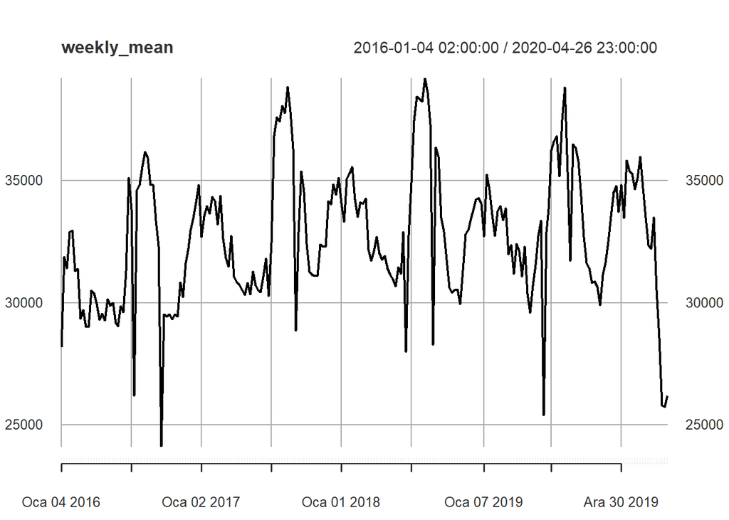

```r
ep_weeks<-endpoints(xts_cons,on="weeks")
weekly_mean<-period.apply(xts_cons,INDEX=ep_weeks,FUN=mean)
plot(weekly_mean)
```

The first insight is that there are very clear seasonal trends. Every year, electricity consumption is high in mid January, reduces significantly as winter passes and lingers at a low amount until the end of June. Then, it rapidly peaks in July and August, remains high until the beginning of Fall season. It is at its relatively lower values until October, when it starts to rise again to reach its high levels in January again.

Also, we can see that there are very specific weeks where the consumption either sinks or peaks. These certainly must be considered while creating a model.

Lastly, a slight increase is observed over years, but this will be discussed later.

## Monthly

For the remaining periods, it is more convenient to compare aggregated values of time periods with same attributes. For example the following plot will show the mean values of every 1st day of all months, 2nd day of all months etc. This will help in understanding whether the location in a specific month matters in terms of electric consumption.

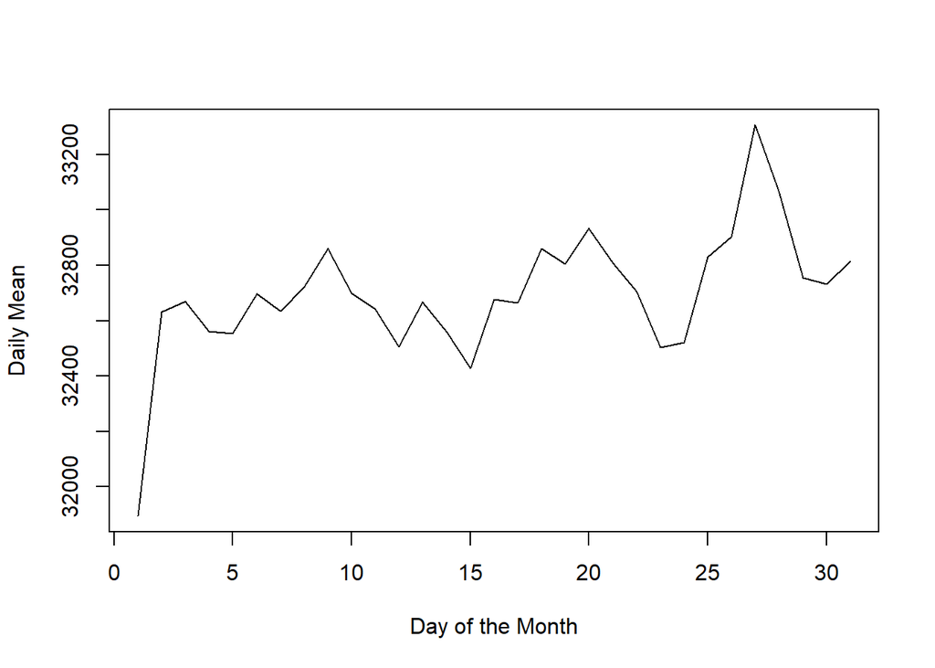

```r
daily<-apply.daily(xts_cons,mean)

library(lubridate)

days<-data.frame()
for(i in 1:31){
days<-rbind(days, mean(daily[mday(daily)==i]))
}
colnames(days)<-"day_mean"
plot(x = rownames(days),y=days$day_mean,type="l",ylab='Daily Mean',xlab='Day of the Month')
```

Apparently, only the first and 27th days of month are significant.

## Weekly

Now let’s check whether the day of the week is a significant predictor. Applying the same procedure:

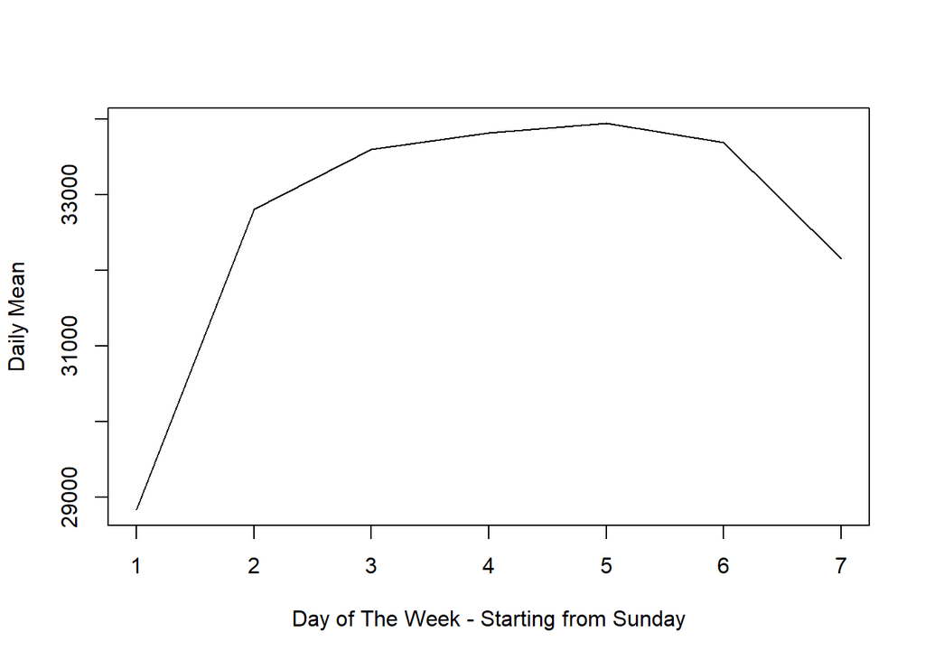

```r
weekdays<-data.frame()
for(i in 1:7){
  weekdays<-rbind(weekdays, mean(daily[wday(daily)==i]))
}
colnames(weekdays)<-"weekday_mean"
plot(x = rownames(weekdays),y=weekdays$weekday_mean,type="l",ylab='Daily Mean',xlab='Day of The Week - Starting from Sunday')
```

Electricity consumption on Saturdays are below weekly average, and on Sundays it is way lesser than average. Other days have similar means.

## Daily

As the final step, electricity consumption according to hours of each day can be summarized as:

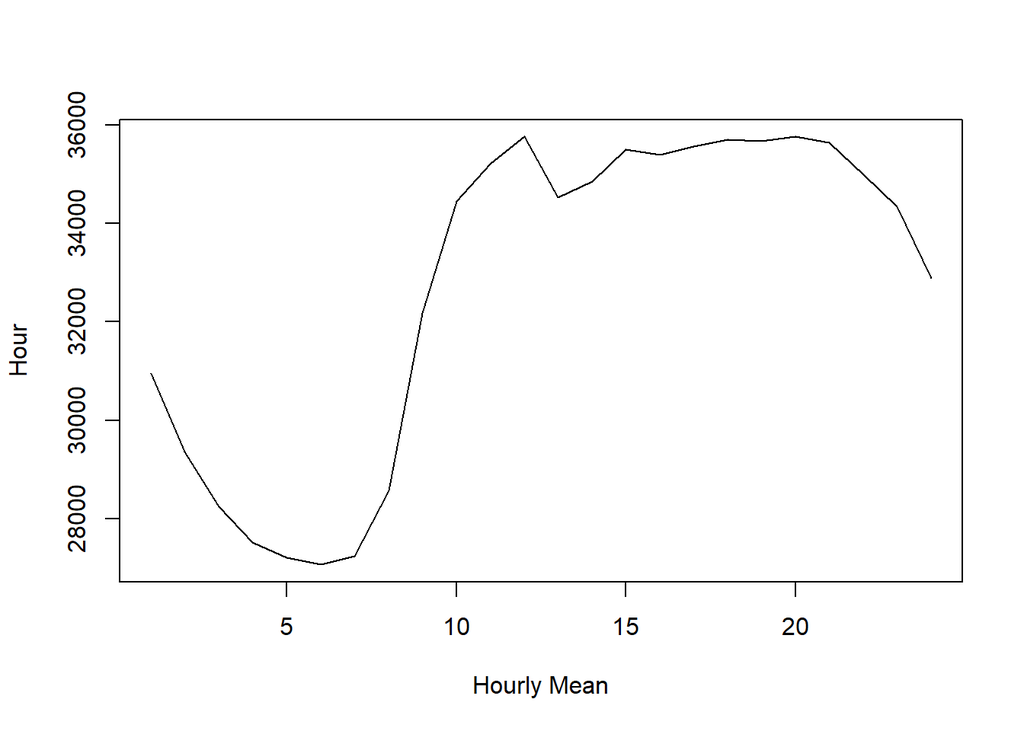

```r
hours<-data.frame()
for(i in 0:23){
  hours<-rbind(hours, mean(xts_cons[as.numeric(hour(xts_cons))==i]))
}
colnames(hours)<-"hour_mean"
plot(x = rownames(hours),y=hours$hour_mean,type="l",xlab='Hourly Mean',ylab='Hour')
```

After 10 A.M., electricity consumption is at its highest until 8 P.M.; then it gradually becomes lower.

# Long Term Trend

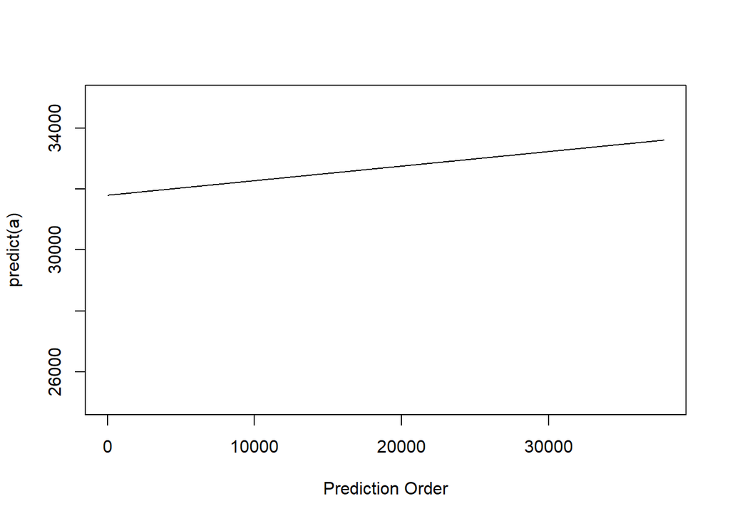

```r
a<-lm(coredata(xts_cons)~index(xts_cons))
plot(y=predict(a),x=index(a$fitted.values),ylim=c(25000,35000),type='l',xlab = 'Prediction Order')
```

# Decomposed View

It is apparent that there are strong cycling trends over a full day, a full week and a full year. In order to take all of these seasonalities into account, assuming a recurring pattern each year will be useful. This means that autocorrelations of up to 24*365 entries before will be meaningful in analyzing each hour’s consumption.

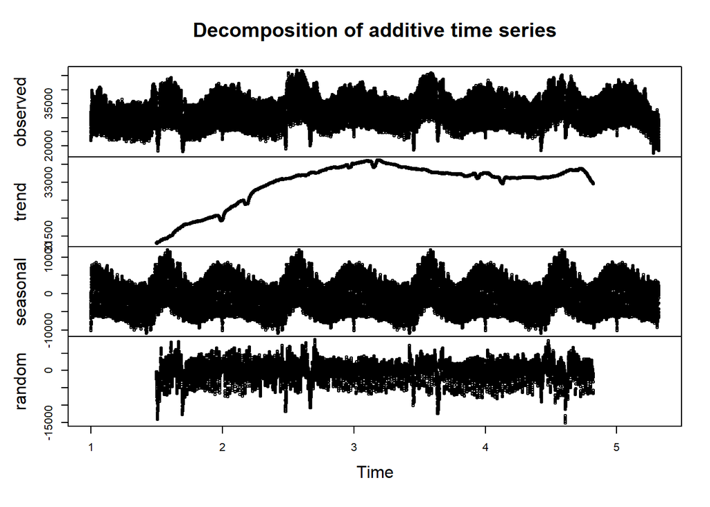

```r
tsdata<-ts(data=consumption_data$Consumption..MWh.,frequency=24*365)
components.ts<-decompose(tsdata,type = 'additive')
plot(components.ts,type="p")
```

Although the visualization looks messy due to the very large number of data points and autocorrelation patterns, random component seems to be close to 0 most of the time. This shows that the series are largely predictable.

# Deseasonalized & Detrended View

Now that the seasonal component is acquired, the series can be converted to its stationary form; the step before fitting an AR or MA model. In order to achieve this, the seasonal component is subtracted from series and the first differences will be taken. Hopefully the result will be a random noise.

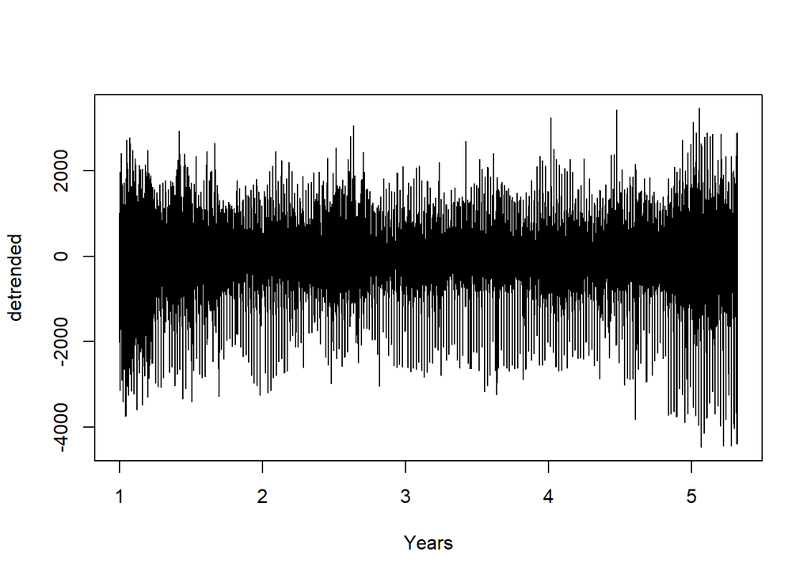

```r
deseasonalized<-tsdata-components.ts$seasonal
detrended<-diff(deseasonalized,differences=1)
plot(detrended,xlab='Years')
```

It looks indeed much like a white noise; although in the end and in the beginning it is more variant. This may be due to the fact that 365 days per year was assumed, however, 2020 and 2016 have 366. Yearly correlations may be disrupted due to this; the days in these ranges take a different day than that of others when they go back by 365 days, and we had already discovered that it matters on which day of the week the observations are made.

# Fitting ARIMA Models

The following code block creates an Arima model on the deseasonalized time series while detrending them inside the Arima function, and forecasts on the next 24 hour period. Then it returns the forecast plot combined with the last 10 days’ electricity consumption values, and the AIC value of the fitted model.Iterating the process with different p values for AR models and different q values for MA models, a solution close to optimality can be obtained.

```r
library(forecast)
deseas<-stl(tsdata,t.window=24*365,s.window='periodic',robust=TRUE)

fit<-0
f <- forecast(deseas, h=24,
              forecastfunction=function(x,h,level){
                fit <<- Arima(x, order=c(1,0,0), include.mean=TRUE,)
                return(forecast(fit,h=24,level=0.95))})

plot(f,include = 240)
```

```r
AIC(object = fit)
```

## Autoregressive Model

AIC value keeps decreasing as the p argument is increased. However, it gets more and more computationally expensive to fit the model. For p>10, the change in AIC is negligible. The resulting forecast and AIC are as following for the (14,0,0) model.

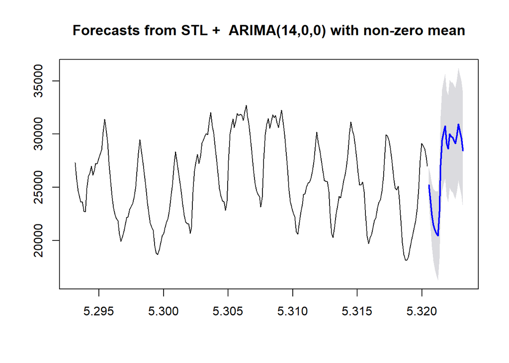

```
## [1] 616211.4
```

## Moving Average Model

The changes in AIC value are more significant in this one; it decreases by about 8% as the model complexity increases.

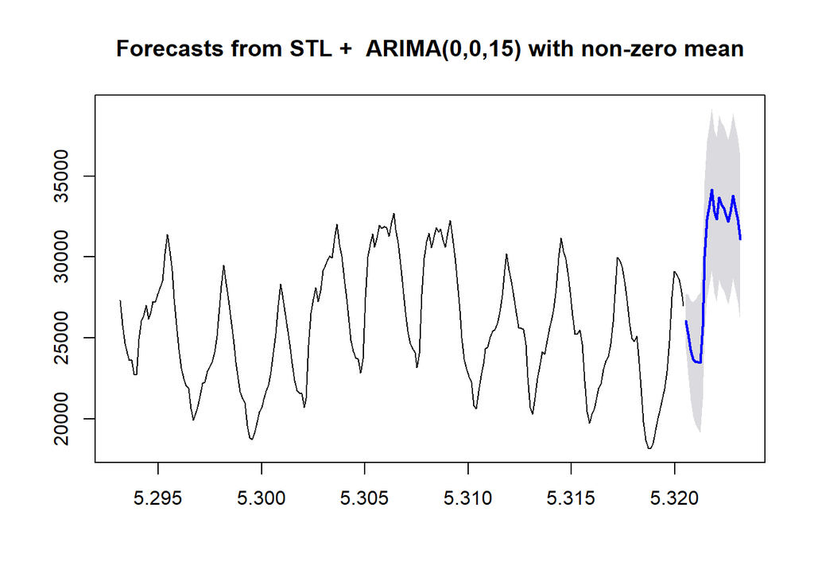

```
## [1] 617658.8
```

## Comparison

AR model seems to be slightly more reliable according to AIC values. Also, when visually compared, upper and lower bounds of AR predictions seem to be more consistent with the previous week’s consumption data. Therefore we can conclude that a pure AR model is preferable over a pure MA model in our case.